# 18mcmt17_assignment2

###### PATTERN RECOGNITION

```
                      ASSIGNMENT --2

                                                         TASLEEM SULTHANA
                                                          18MCMT17(MTECH_CS)
```

```python
import numpy as np
import matplotlib.pyplot as plt
from sklearn.preprocessing import StandardScaler
```

###### (1) Implement dimensionality reduction techniques such as Principal Component Analysis(PCA) and Fisher’s Linear Discriminant Analysis (LDA) using your own code.

PCA ALGORITHM: 1.standardizing the given data and calculating the mean adjuested matrix here in for implementing pca we are using standarscaler of sklearn.preprocessing library /# scaler = StandardScaler() std_data = scaler.fit_transform(data) mean_vec = np.mean(std_data, axis=0) #/

2.finding the covariance matrix /#cov_mat = np.cov(std_data.T) #/

3.finding the eigen_vectors and eigen values /# eig_vals, eig_vecs = np.linalg.eig(cov_mat) #/

4.sorting the eigpairs and getting the max values that covers most of data /# eig_pairs = ([(np.abs(eig_vals[i]), eig_vecs[:,i]) for i in range(len(eig_vals))] eig_pairs.sort() eig_pairs.reverse() eig_vecs = np.array([eig_pairs[i][1] for i in range(num_dims)]) #/

5.finding the new matrix /# pca_data=(std_data).dot(eig_vecs.T) #/

```python
def EIG_PAIRS(eig_vals, eig_vecs):
    eig_pairs = [(np.abs(eig_vals[i]), eig_vecs[:,i]) for i in range(len(eig_vals))]
    print(eig_pairs)
    print("\n")
    eig_pairs.sort()
    print(eig_pairs)
    print("\n")
    eig_pairs.reverse()
    print(eig_pairs)
    return eig_pairs
#     return [x[0] for x in eig_pairs], [y[1] for y in eig_pairs]

def PCA(data,num_dims):
    print(data.shape)
    scaler = StandardScaler()
    std_data = scaler.fit_transform(data)                      #standardizing
    mean_vec = np.mean(std_data, axis=0)
    cov_mat = np.cov(std_data.T)                                     #finding covariance matrix
    eig_vals, eig_vecs = np.linalg.eig(cov_mat)             #CALCULATING EIGEN VALUES AND VECTORS.
    eig_pairs=EIG_PAIRS(eig_vals, eig_vecs)
    eig_vecs = np.array([eig_pairs[i][1] for i in range(num_dims)])

    pca_data=(std_data).dot(eig_vecs.T)
    print(pca_data.shape)
    return pca_data
```

FLDA ALGORITM:

2.summing up the with-in class covariance matrix and between class covariance matrix /# S_B = S_B1 + S_B2 + S_B3... S_W = S_W1 + S_W2 + S_W3.. #/

3.Finding the multiplication of inv(S_W).S_B /# mat = np.dot(np.linalg.pinv(S_W), S_B) #/

4.finding the eigen vectors and eigen values /# eigvals, eigvecs = np.linalg.eig(mat) #/

5.finding the eigen pairs and sorting them /# eig_pairs = [(eigvals[i], eigvecs[:, i]) for i in range(len(eigvals))] eig_pairs = sorted(eig_pairs, key = lambda x : x[0], reverse = True) #/

6.finding the new data /# fld_data=data.dot(eig_pairs[0][1]) #/

```python
def fld_params(data,total_mean):
    mean=np.mean(data,axis=0)

    # calculate within class covariance matrix S_B = \sigma{N_i (x - m) (x - m).T}
    s_w=((data-mean).T).dot(data-mean)

    #   calculate between class covariance matrix S_W = \sigma{N_i (m_i - m) (m_i - m).T}
    s_b=((total_mean-mean).T).dot(total_mean-mean)
    return s_w,s_b


def FLDA(data):
    total_mean=np.mean(data,axis=0)
    s_w1,s_b1=fld_params(data[:50],total_mean)
    s_w2,s_b2=fld_params(data[50:100],total_mean)
    s_w3,s_b3=fld_params(data[100:150],total_mean)
    S_W=(s_w1+s_w2+s_w3)
    S_B=50*(s_b1+s_b2+s_b3)
    # objective : find eigenvalue, eigenvector pairs for inv(S_W).S_B
    mat = np.dot(np.linalg.pinv(S_W), S_B)
    eigvals, eigvecs = np.linalg.eig(mat)
    eig_pairs = [(eigvals[i], eigvecs[:, i]) for i in range(len(eigvals))]
    eig_pairs = sorted(eig_pairs, key = lambda x : x[0], reverse = True)
    fld_data=data.dot(eig_pairs[0][1])
    return fld_data
```

###### (2) Apply PCA and LDA on IRIS dataset. Show projection of the original data in PCA space(PC1 versus PC2; PC1 versus PC3 and PC2 versus PC3) and 1-dimensional LDA space.Please label each point with their class labels for better visualization. Now, comment onthe similarities and differences of results obtained in these two approaches.

```python
iris_data = np.genfromtxt("datasets/iris.csv",delimiter=",",skip_header=1)
iris_data = iris_data[:,:4]
print(iris_data.shape)
```

```
(150, 4)
```

```
(150, 4)
[(2.9303537755893188, array([ 0.52237162, -0.26335492,  0.58125401,  0.56561105])), (0.9274036215173411, array([-0.37231836, -0.92555649, -0.02109478, -0.06541577])), (0.1483422264816396, array([-0.72101681,  0.24203288,  0.14089226,  0.6338014 ])), (0.020746013995596033, array([ 0.26199559, -0.1241…


[(0.020746013995596033, array([ 0.26199559, -0.12413481, -0.80115427,  0.52354627])), (0.1483422264816396, array([-0.72101681,  0.24203288,  0.14089226,  0.6338014 ])), (0.9274036215173411, array([-0.37231836, -0.92555649, -0.02109478, -0.06541577])), (2.9303537755893188, array([ 0.52237162, -0.2633…


[(2.9303537755893188, array([ 0.52237162, -0.26335492,  0.58125401,  0.56561105])), (0.9274036215173411, array([-0.37231836, -0.92555649, -0.02109478, -0.06541577])), (0.1483422264816396, array([-0.72101681,  0.24203288,  0.14089226,  0.6338014 ])), (0.020746013995596033, array([ 0.26199559, -0.1241…
(150, 3)
```

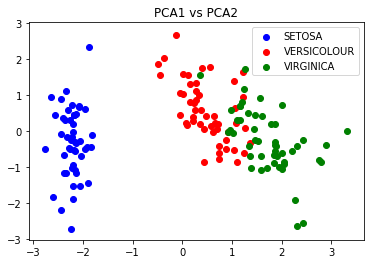

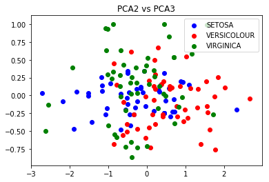

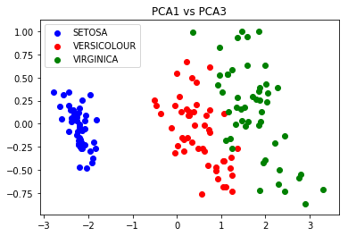

```python
def pca_plot(pca_d1,pca_d2,pca_d3,pca_d4,pca_d5,pca_d6,title,x_l,y_l):
    plt.title(title)
    plt.scatter(x=pca_d1, y=pca_d2,c="b",label="SETOSA")
    plt.scatter(x=pca_d3, y=pca_d4,c="r",label="VERSICOLOUR")
    plt.scatter(x=pca_d5, y=pca_d6,c="g",label="VIRGINICA")
    plt.legend()
    plt.show()

def pca_main(iris_data):
    pca_data=PCA(iris_data,3)
    pca_plot(pca_data[:50,0],pca_data[:50,1],pca_data[50:100,0],pca_data[50:100,1],pca_data[100:150,0],pca_data[100:150,1],"PCA1 vs PCA2","PCA1","PCA2")
    pca_plot(pca_data[:50,1],pca_data[:50,2],pca_data[50:100,1],pca_data[50:100,2],pca_data[100:150,1],pca_data[100:150,2],"PCA2 vs PCA3","PCA2","PCA3")
    pca_plot(pca_data[:50,0],pca_data[:50,2],pca_data[50:100,0],pca_data[50:100,2],pca_data[100:150,0],pca_data[100:150,2],"PCA1 vs PCA3","PCA1","PCA3")

pca_main(iris_data)
```

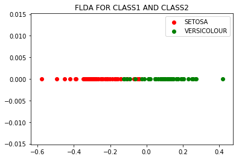

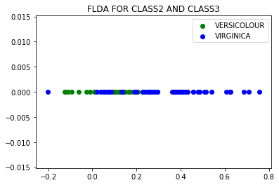

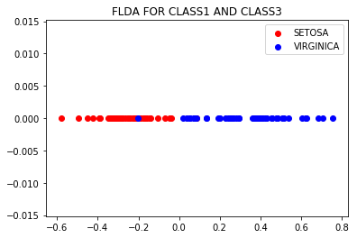

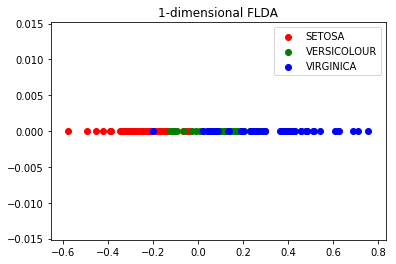

```python
def flda_plot(flda_d1,flda_d2,title,label1,label2,c1,c2):
    plt.title(title)
    Y=np.zeros(50)
    plt.scatter(x=flda_d1, y=Y,c=c1,label=label1)
    plt.scatter(x=flda_d2, y=Y,c=c2,label=label2)
    plt.legend()
    plt.show()
def plot_flda(flda_d1,flda_d2,flda_d3):
    plt.title("1-dimensional FLDA")
    Y=np.zeros(50)
    plt.scatter(x=flda_d1, y=Y,c="r",label="SETOSA")
    plt.scatter(x=flda_d2, y=Y,c="g",label="VERSICOLOUR")
    plt.scatter(x=flda_d3, y=Y,c="b",label="VIRGINICA")
    plt.legend()
    plt.show()
def flda_main(iris_data):
    flda_data=FLDA(iris_data)
#     plot_actual_data(iris_data)
    flda_plot(flda_data[:50],flda_data[50:100],"FLDA FOR CLASS1 AND CLASS2","SETOSA","VERSICOLOUR","r","g")
    flda_plot(flda_data[50:100],flda_data[100:150],"FLDA FOR CLASS2 AND CLASS3","VERSICOLOUR","VIRGINICA","g","b")
    flda_plot(flda_data[:50],flda_data[100:150],"FLDA FOR CLASS1 AND CLASS3","SETOSA","VIRGINICA","r","b")
    plot_flda(flda_data[:50],flda_data[50:100],flda_data[100:150])
flda_main(iris_data)
```

###### (4) Use kernel PCA (kPCA) and Local Linear Embedding (LLE) from any python package (forexample, scikit-learn)on synthetic datasets (such as 3D swissroll dataset). Compare theresults from your PCA with those of kPCA and LLE. You can also experiment byintroducing punctures in the swiss roll manifold to see what ordinary PCA versus kPCA and LLE do to this data in 2D projection.

implementing lle,pca,kpca: pca is implemented by using my code written for the question 1 kpca,and lle are implemented using the available functions

Locally-linear embedding:  
finds a set of the nearest neighbors of each point. then computes a set of weights for each point that best describes the point as a linear combination of its neighbors. it uses an eigenvector-based optimization technique to find the low-dimensional embedding of points, such that each point is still described with the same linear combination of its neighbors.

pca: it standardizes the data gets the covariance matrix ,eigenvec and values og the covariance matrix and forms new dataset using the eigen pair values.higher vector values which cover to the maximum are consider.

relation between kpca and pca: KPCA(K)==PCA(X⊤)

kpca can extract non linear principal components

```python
from sklearn import manifold,datasets
from mpl_toolkits.mplot3d import Axes3D

def plot_swiss_lle(swiss_data, color,swiss_r):
    fig = plt.figure(1,figsize=(10,8))
    ax = fig.add_subplot(211, projection='3d')
    ax.scatter(swiss_data[:, 0], swiss_data[:, 1], swiss_data[:, 2], c=color, cmap=plt.cm.Spectral)
    ax.set_title("Original data")
    ax = fig.add_subplot(212)
    ax.scatter(swiss_r[:, 0], swiss_r[:, 1], c=color, cmap=plt.cm.Spectral)
    plt.axis('tight')
    plt.title('modified lle data')
    plt.show()

def plot_swiss(swiss_data,title):
    plt.title(title)
    plt.xlabel("pca1")
    plt.ylabel("pca2")
    plt.scatter(swiss_data[0],swiss_data[1],c=color ,cmap=plt.cm.Spectral)
    plt.show
```

```
Computing LLE embedding
Reconstruction error: 2.19668e-07
```

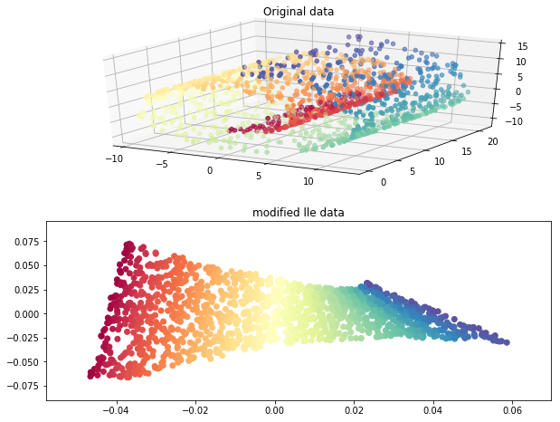

```python
swiss_data, color = datasets.samples_generator.make_swiss_roll(n_samples=1500)
def lle(swiss_data, color):
    print("Computing LLE embedding")
    swiss_r, err = manifold.locally_linear_embedding(swiss_data, n_neighbors=20,n_components=2)
    print("Reconstruction error: %g" % err)
    plot_swiss_lle(swiss_data, color,swiss_r)
lle(swiss_data, color)
```

```
(2, 1500)
```

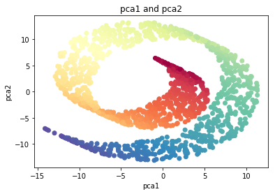

```python
def pca(swiss_data, color):
    scaler = StandardScaler()
    std_data = scaler.fit_transform(swiss_data)                      #standardizing
    mean_vec = np.mean(std_data, axis=0)
    cov_mat = np.cov(std_data.T)                                     #finding covariance matrix
    eig_vals, eig_vecs = np.linalg.eig(cov_mat)             #CALCULATING EIGEN VALUES AND VECTORS.
    mat=eig_vecs[:,:2]
    swiss_data_pca=(mat.T).dot(swiss_data.T)
    print(swiss_data_pca.shape)
    plot_swiss(swiss_data_pca,"pca1 and pca2")
pca(swiss_data, color)
```

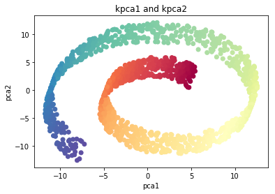

```python
from sklearn.decomposition import KernelPCA
def kpca(swiss_data):
    conver=KernelPCA(n_components=2,kernel="linear")
    swiss_data_kpca=conver.fit_transform(swiss_data)
    swiss_data_kpca=swiss_data_kpca.T
    plot_swiss(swiss_data_kpca,"kpca1 and kpca2")

kpca(swiss_data)
```

###### (3) Apply PCA to a high dimensional dataset such as UCI Arcene cancer classification data.Generate the Scree Plot. Comment on how many components to choose for explaining85%, 90%, 95% and 99% of the variance of the data. Project the data into first two PCs as well as 1-dimensional LDA space (To avoid clutter, plot only 10% of the data but equal number from each class. Use class labels on the data points to visualize better) and comment on the “representation” of the data in the lower dimensional subspace.

```python
def scree_plot(data):
    no_of_features = data.shape[1]
    cov_mat = np.cov(data.T)
    eig_vals, eigen_vecs = np.linalg.eig(cov_mat)
    eig_pairs=EIG_PAIRS(eig_vals, eig_vecs)
    eig_vals, eig_vecs = [x[0] for x in eig_pairs], [y[1] for y in eig_pairs]
    plt.plot(np.arange(len(eig_vals)) + 1, eig_vals, 'ro-')
    plt.title('Plotting  arcene eigens')
    plt.xlabel('Principal Component')
    plt.ylabel('Eigen Values')
    plt.show()
    return eig_vals, eig_vecs
```

```python
file = open('datasets/arcene_train.data')
trainData = np.array([list(map(int, file.readline().strip().split(' '))) for _ in range(100)])
print(trainData.shape)
file = open('datasets/arcene_train.labels')
trainLables = np.array([int(file.readline().strip()) for _ in range(100)])
print(trainLables.shape)
class1 = trainData[trainLables == 1]
class2 = trainData[trainLables == -1]
print(class1.shape)
cancer_data = np.vstack((class1,class2))
print(cancer_data.shape)
eigen_values, eigen_vectors = scree_plot(trainData)
```

[output not shown]

```python
def print_variance_coverage(eigen_values, eigen_vectors):
    print('Variance Coverage:\n')
    eigv_sum = sum(eigen_values)
    var = np.cumsum(eigen_values)/eigv_sum *100
    print(np.where(var >= 85))
    print(np.where(var >= 90))
    print(np.where(var >= 95))
    print(np.where(var >= 99))
    print(np.where(var >= 100)



print_variance_coverage(eigen_values, eigen_vectors)
```

[output not shown]